# **30535 Skills Problem Set 1**

### 2.5.2

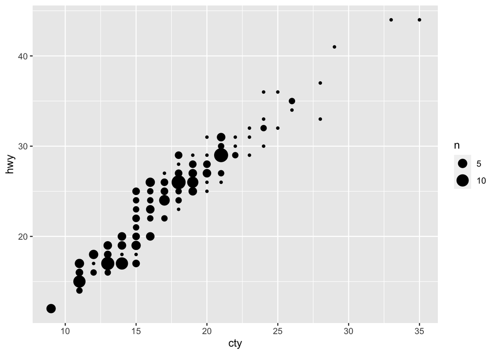

```r
ggplot(data = mpg, mapping = aes(x = cty, y = hwy)) +
  geom_count()
```

*Interpretation*

- Both of them will make positional adjustment to the plot and make the plot indicate the number of cases in each combination.
- geom_count() adjust point sizes based the number of observations in the combination. The more observations, the larger the point size. The legend will also show the number of observations with different point size. However, if the points are too close, or the observations are large, overplotting will occur again.
- geom_jitter() will slightly change poin positions to resolve the overplotting problem. In some cases it will be better than geom_count
- Overall, both are not perfect solution to overplotting.geom_count()does not change the point position while will lead to potential overplotting problem; geom_jitter() will be more effective to avoid overplotting but it will make slight change to the point position and will not allow us to recognize the exact number of observations.  
  *Reference*  
  https://stackoverflow.com/questions/39255781/what-is-difference-between-geom-point-and-geom-jitter-in-simple-language-in-r

### 2.5.3

The default setting is position_stack, which means if multiple bars occupying the same position(group) then R will stack them atop of one another. We use position_dodge() to dodge overlapping bars side by side, or use position_fill() to stack bars in a way to show the proportional values of each category within each x group, and standardize each bar to have same heights. Adding position_fill() will generate a plot with 1 bar for each x group.  
*Reference: R help function*

### 2.6

### 2.6.1

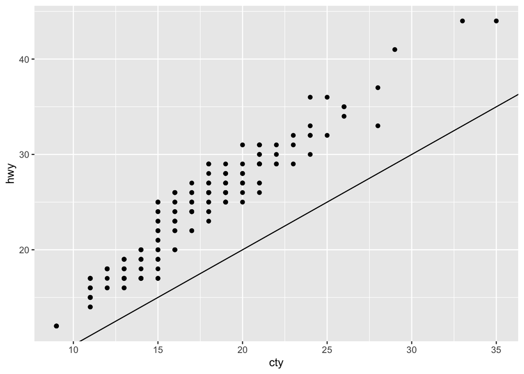

```r
ggplot(data = mpg, mapping = aes(x = cty, y = hwy)) +
  geom_point() +
  geom_abline()
```

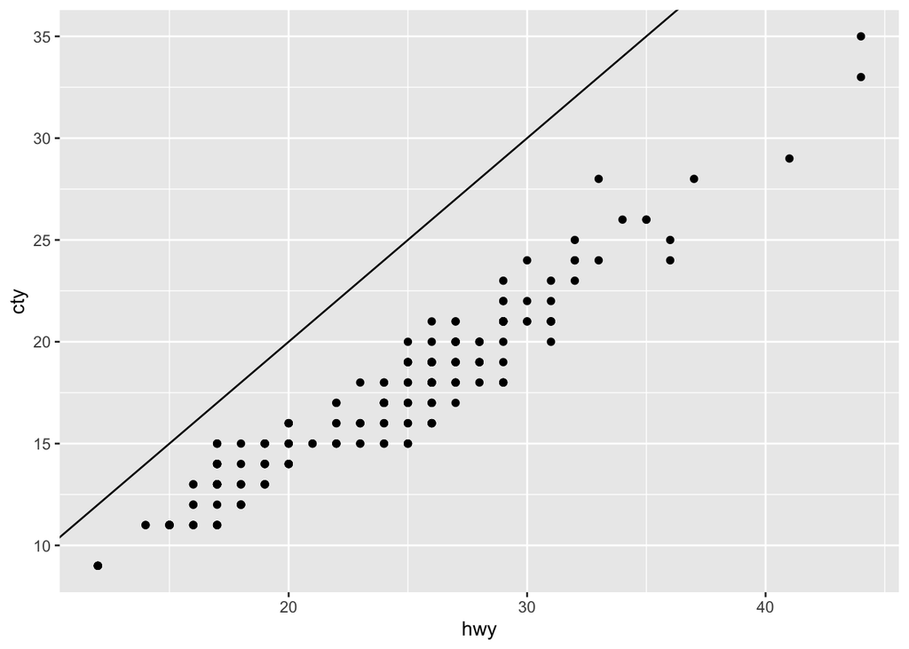

```r
ggplot(data = mpg, mapping = aes(x = cty, y = hwy)) +
  geom_point() +
  geom_abline() +
  coord_flip()
```

*Interpretation*  
If we use coord_flip(), the x axis and y axis will be switched, i.e., the initial x variable now becomes the y variable, and y variable becomes the x variable.

### 2.6.2

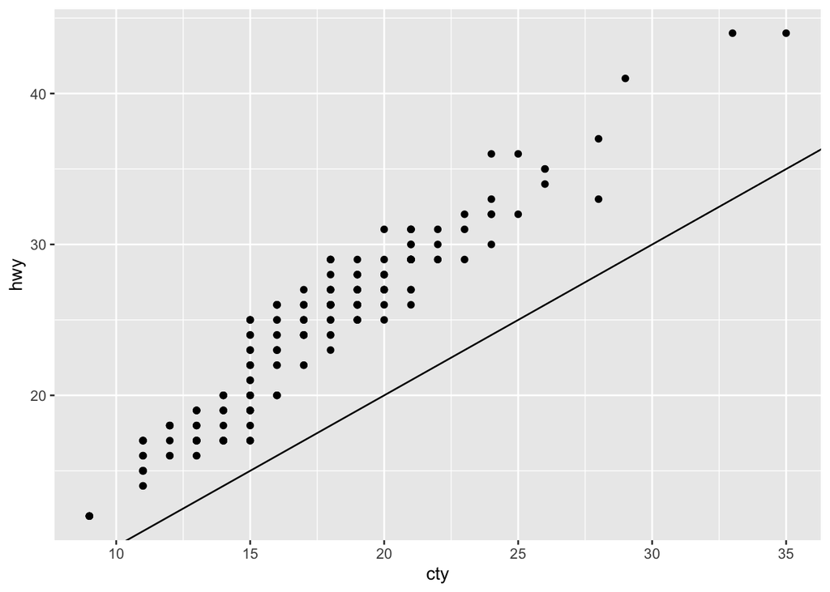

```r
ggplot(data = mpg, mapping = aes(x = cty, y = hwy)) +
  geom_point() +
  geom_abline()
```

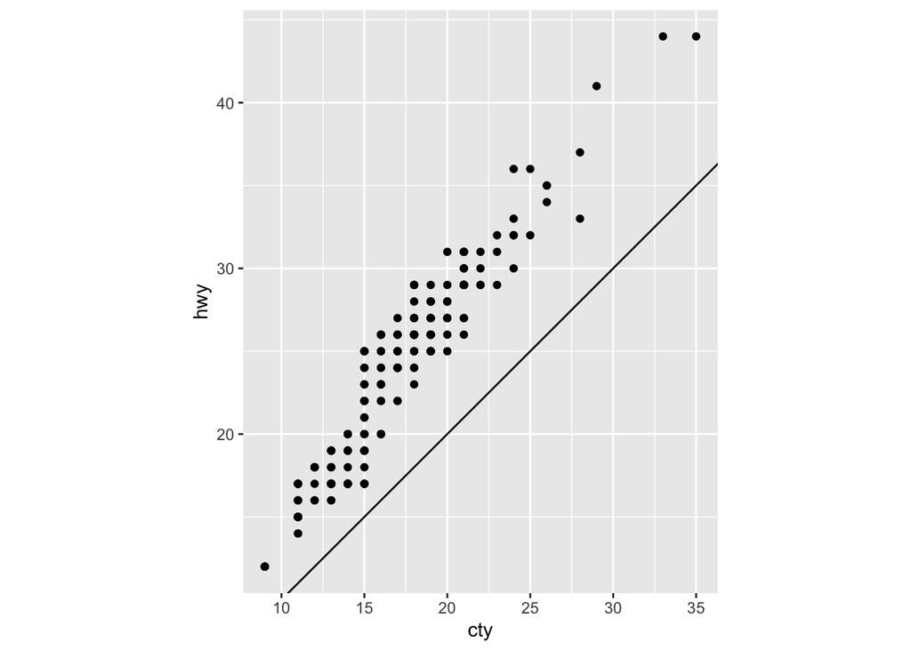

```r
ggplot(data = mpg, mapping = aes(x = cty, y = hwy)) +
  geom_point() +
  geom_abline() +
  coord_fixed()
```

*Interpretation*  
The plot shows that there is a positive correlation between city and highway mpg. The more city miles per gallon, we would expect the more highway miles per gallon.

- geom_abline() creates a reference line for the plot. The line could be vertical, horizontal or specified with slope and intercept
- coord_fixed() ensures that the reference line is at 45-degree angle, which makes it easier for us to compare the differences between observed hwy and the case that hwy equal to cty, given cty constant